# Como os biocombustíveis podem ajudar a diminuir a poluição

Como os biocombustíveis podem ajudar a diminuir a poluição

Leonardo Carletto

20/06/2026

Capa e encerramento: frames do vídeo *Are efforts to reduce carbon dioxide emissions working? How would we know?* — ARCHIVED · NASA Climate Change.

## Automóveis a combustão e suas consequências

Na sociedade moderna, a emissão de poluentes e derivados de combustíveis fósseis advinda de veículos a combustão é, sem dúvida, um dos desafios da modernidade. As consequências do uso em larga escala dessas fontes de energia causam impactos significativos e preocupantes na nossa sociedade, principalmente nos grandes centros urbanos. Os principais impactos são a poluição ambiental, as chuvas ácidas, a poluição do ar e a emissão de gases de efeito estufa (Sunne, 2024), além dos problemas causados por erros humanos, como o vazamento de óleo e petróleo em refinarias e navios de extração, que, como consequência, contaminam os mares e oceanos, tornando as áreas afetadas em lugares inóspitos à vida (Brasil 247, 2019). Essas consequências são bem evidenciados na segunda edição do relatório **Do Berço ao Túmulo: o impacto dos combustíveis fósseis na saúde**, produzido pela (Global Climate and Health Alliance, 2025, pp. 34, 38, 71, 74), uma coalizão internacional que busca combater as mudanças climáticas e atingir melhorias na área de saúde pública.

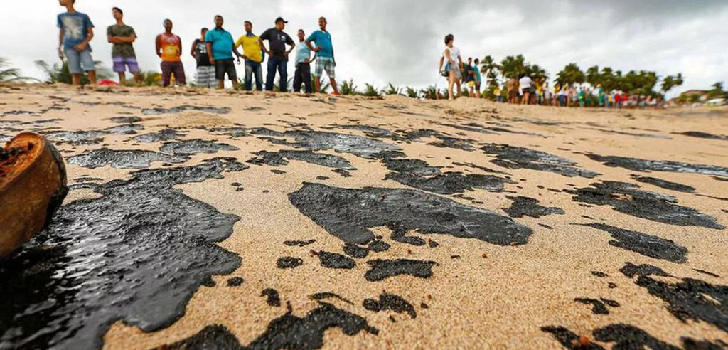

Grupo de Trabalho participa de ações para retirada de óleo na Costa dos Corais em Alagoas. | Crédito: Felipe Brasil/ Fotos Públicas

No Brasil, o **Proconve**, criado em 1986 com o objetivo de diminuir a poluição veicular, completou recentemente 40 anos (Ibama, 2022) , e seus impactos são extremamente positivos. O nível de emissão de monóxido de carbono por quilômetro rodado chegava a **54 g/km por veículo**; considerando os **13 milhões de veículos da época**, os números chegavam a aproximadamente **702 kg do poluente** para um único veículo em um ano, e cerca de **9.126.000,00** de toneladas para o total da frota anual. Atualmente, o nível de emissão está em cerca de **0,4 g/km por veículo**, o que representa uma redução superior a **98%** em relação ao início da implementação do programa para um **único veículo**. Considerando a frota atual de **129 milhões** de veículos, um veículo polui cerca de **5,2 kg em um ano**, e toda a frota cerca de **670.800,00** toneladas — uma redução de pelo menos **92%** em comparação aos valores anteriores à implementação da lei, segundo dados do (Ibama, 2026).

O monóxido de carbono emitido pelos automóveis a combustão, é um gás tóxico, e o **catalisador automotivo** (TotalEnergies, 2023) — imposto pelas regras do **Proconve** o converte em dióxido de carbono (CO₂), um gás que, embora poluente, não é tóxico da mesma forma. Na prática, o catalisador apenas antecipa o que aconteceria inevitavelmente na atmosfera: a reação do CO com o oxigênio, que o transforma em CO₂. Essa mudança, por si só, já trouxe melhorias para o ar respirado, especialmente nas grandes metrópoles. Outras soluções foram implementadas com o passar dos anos, como a melhoria da qualidade do combustível, a adição de etanol à gasolina e de biodiesel ao diesel,e a popularização do Etanol (Raízen, 2022) devido ao Proálcool (Ministério de Minas e Energia, 2014). Essas mudanças representaram melhorias incomparáveis em relação ao que existia antes do Proconve.

## A base de dados

Os dados utilizados são do **PBEV 2026 - Programa Brasileiro de Etiquetagem Veicular** (INMETRO, 2026) , mantido pelo **INMETRO** em parceria com o **Programa CONPET da Petrobras**, **Ministério de Minas e Energia**, **Ministério do Meio Ambiente** e do **Ibama**. Os valores de consumo e emissão são obtidos a partir de **ensaios laboratoriais padronizados**. Uma explicação mais detalhada do que é o PBEV, pode ser encontrada no site do INEE - Instituto Nacional de Eficiência Energética (Rogério, 2025).

## Objetivo

O foco desta análise exploratória, foi investigar como o uso do biocombustível **etanol** pode impactar na **diminuição da poluição** em comparação aos **combustíveis fósseis (óleo diesel e gasolina)**, quantificar os impactos anuais da emissão de poluentes desses combustíveis por **categoria de veículo** e medir a **quantidade de combustível por quilômetro rodado em cada categoria**.

Na base analisada, as variáveis selecionadas para este estudo foram:

- **Categoria** — classe do veículo;
- **Emissão de CO₂ do etanol** (g/km) e **emissão de CO₂ da gasolina/diesel** (g/km);
- **Emissão de CO₂ fóssil do etanol** (g/km) e **emissão de CO₂ fóssil da gasolina/diesel** (g/km);
- **Consumo combinado** (cidade + estrada) **do etanol** (km/l) e **da gasolina/diesel** (km/l).
- **Veiculos eletricos não foram considerados nessa analise**.

## Resultados

### Distribuição das emissões de CO₂ por categoria

Os gráficos abaixo têm como objetivo estudar a **frequência** das emissões de CO₂ por categoria, separadamente para etanol e para gasolina/diesel.

[interactive chart not shown]

As distribuições mostram que, para a maioria das categorias, a emissão de CO₂ por quilômetro da gasolina/diesel se concentra em **patamares mais altos** do que a emissão do etanol, indício de que o etanol tende a poluir menos por quilômetro rodado.

### Consumo de combustível por categoria

Os gráficos a seguir têm como objetivo **comparar o consumo (km/l) entre as categorias**, separando etanol de gasolina/diesel. Foram consideradas apenas categorias com pelo menos 3 veículos e os valores ausentes (NA) foram removidos.

[interactive chart not shown]

Observa-se que o rendimento do etanol **(entre cerca de 5,7 e 11,9 km/l)** é, de modo geral, inferior ao rendimento da gasolina/diesel **(entre cerca de 4,7 e 17,2 km/l)**: com etanol, percorre-se menos quilômetros por litro. Esse é um ponto de atenção, pois a vantagem ambiental por quilômetro convive com um consumo maior de combustível.

Nesse cenário de necessidade de renovação energética limpa no Brasil, o etanol — um biocombustível de matéria-prima vegetal, produzido por meio da fermentação do amido ou de outros açúcares de origem vegetal — destaca-se por ser um combustível sustentável, renovável e pouco poluente em comparação com os combustíveis fósseis, unindo a necessidade por energias renováveis e menos poluentes à capacidade de produção do etanol brasileiro. Vale lembrar que, diferentemente dos combustíveis fósseis, que têm uma finitude, o etanol é renovável e também uma fonte de energia mais limpa, pois sua produção emite até 80% menos poluentes — quando comparado à gasolina e ao óleo diesel.

### Emissão média anual de CO₂ por categoria

A tabela abaixo tem como objetivo **quantificar a emissão média anual de CO₂** de cada categoria e o quanto, em média, seria evitado com o uso do etanol. **Todos os valores são médias por categoria.**

Emissão média de CO₂ por categoria veicular

Médias estimadas em kg de CO₂ por ano, considerando 13.000 km rodados

| Categoria | Etanol Total (kg/ano) | Etanol Fóssil (kg/ano) | Gasolina/Diesel Total (kg/ano) | Gasolina/Diesel Fóssil (kg/ano) | CO₂ médio evitado com etanol (kg/ano) |  |
| --- | --- | --- | --- | --- | --- | --- |
| Comercial | 1.633,7 | 0,0 | 2.404,0 | 1.410,5 |  | 770,3 |
| Compacto | 1.430,0 | 0,0 | 1.584,6 | 1.303,4 | 154,6 |  |
| Esportivo | - | - | 2.731,6 | 2.248,4 | - |  |
| Extra Grande | 1.751,8 | 0,0 | 1.939,1 | 1.597,1 | 187,4 |  |
| Fora de Estrada Compacto | 2.106,0 | 0,0 | 2.236,0 | 1.846,0 | 130,0 |  |
| Fora de Estrada Grande | 2.128,3 | 0,0 | 2.657,3 | 2.217,3 | 529,0 |  |
| Grande | 1.465,3 | 0,0 | 1.668,1 | 1.372,6 | 202,8 |  |
| Médio | 1.473,3 | 0,0 | 1.540,5 | 1.267,7 | 67,2 |  |
| Minivan | 1.781,0 | 0,0 | 1.892,8 | 1.554,8 | 111,8 |  |
| Picape | 2.011,8 | 0,0 | 2.528,9 | 1.887,0 | 517,2 |  |
| Picape Compacta | 1.626,4 | 0,0 | 1.695,1 | 1.392,4 | 68,6 |  |
| Sub Compacto | 1.326,0 | 0,0 | 1.404,0 | 1.157,0 | 78,0 |  |
| Utilitário Esportivo Compacto | 1.556,9 | 0,0 | 1.640,4 | 1.349,7 | 83,5 |  |
| Utilitário Esportivo Grande | 1.788,5 | 0,0 | 1.832,5 | 1.507,8 | 44,0 |  |
| Utilitário Esportivo Grande 4x4 | - | - | 1.281,5 | 1.024,6 | - |  |

Os valores são MÉDIAS por categoria: a emissão média de CO₂ (g/km) de cada combustível foi multiplicada por 13.000 km e dividida por 1.000, resultando na média de kg de CO₂ por ano.  
CO₂ total = emissão total no escapamento (inclui a parcela biogênica); CO₂ fóssil = apenas a parcela de origem fóssil. Por ser renovável, o etanol tem CO₂ fóssil ≈ 0; a gasolina brasileira (E30) já desconta os ~30% de etanol na coluna fóssil. Médias calculadas com os dados disponíveis.  
Fonte: INMETRO, Programa Brasileiro de Etiquetagem Veicular (PBEV 2026) — https://dados.inmetro.gov.br/programa_brasileiro_de_etiquetagem/VEICULOS_2026.csv  
"-" = não há dados de etanol para a categoria (sem veículos flex/etanol).

A tabela confirma a leitura dos gráficos: em **todas as categorias com dados de etanol**, a emissão média do etanol é menor que a da gasolina/diesel, ou seja, o CO₂ médio evitado é positivo. As maiores reduções aparecem nas categorias **Comercial** (cerca de 770 kg de CO₂/ano), **Fora de Estrada Grande** (≈ 529) e **Picape** (≈ 517), enquanto as menores ocorrem em **Utilitário Esportivo Grande** (≈ 44) e **Médio** (≈ 67). E se consideramos, as emissões fósseis, que seriam um novo carbono que será introduzido na atmosfera, as diferenças são enormes.

[figure not shown]

A animação acima ilustra a entrada e saída de carbono na atmosfera.

O **ciclo do carbono**: a queima de **combustíveis fósseis** devolve à atmosfera o carbono que estava “preso” no subsolo (carbono “novo”), enquanto o carbono do **etanol** circula no ciclo natural (fotossíntese <-> respiração). Uma melhor visualização de como a problemática da emissao do co2 fóssil impacta o planenta, pode ser observada nos **dados de monitoramento atmosférico da NASA**, que registram o aumento contínuo das concentrações de CO₂ e metano e da temperatura global ao longo das décadas (NASA Science Earth Indicators, 2026).

## Conclusão

A análise exploratória do PBEV 2026 sugere que o **etanol emite, em média, menos CO₂ por quilômetro do que a gasolina e o diesel em todas as categorias analisadas**, e por ser um combustível renovável, também não emite nenhum CO₂ “novo” na atmosfera. Os ganhos ambientais são maiores nas categorias mais pesadas (comerciais e picapes). Por outro lado, o **rendimento (km/l) do etanol é menor**, o que mostra que a vantagem ambiental por quilômetro precisa ser avaliada junto ao maior volume de combustível consumido.

Entre os **desafios** encontrados, destacam-se a grande quantidade de valores ausentes na emissão do etanol diversas versões não possuem esse dado, por não serem flex/etanol) e a presença de categorias com poucos veículos, o que limita comparações estatísticas mais robustas.

Para **futuras análises**, podem ser consideradas os valores dos combustíveis, permitindo avaliar o custo por quilômetro de cada categoria. E também, a comparação Ano a Ano das categorias, no diz que respeito a emissao de co2 e co2 fóssil, para comparar os efeitos das regulamentações.

## Uso de inteligência artificial

Para a elaboração deste relatório, foi utilizada a ferramenta de inteligência artificial Claude (Opus 4.8), empregada na revisao da sintaxe, na organização e disposição do texto. Na disposição do geom_density_ridges e do geom_boxplot para que ficassem lado a lado sem perder a interatividade com o ggiraph, além de “desbugar” o posicionamento, que não estava na mesma linha e na ilustração interativa sobre o ciclo do carbono.

## Referências

BRASIL 247. **Impacto ambiental e social do óleo vazado ainda é incalculável**. Brasil 247, 2019. Disponível em: <https://www.brasil247.com/brasil/impacto-ambiental-e-social-do-oleo-vazado-ainda-e-incalculavel-afirmam-entidades>

GLOBAL CLIMATE AND HEALTH ALLIANCE. **Do Berço ao Túmulo: o impacto dos combustíveis fósseis na saúde**. Global Climate & Health Alliance, 2025. Disponível em: <https://climateandhealthalliance.org/wp-content/uploads/2025/09/C2G-Report-low-res-Portuguese.pdf>

IBAMA. **Programa de controle de emissões veiculares (Proconve)**. Companhia Ambiental do Estado de São Paulo, 2022. Disponível em: <https://www.gov.br/ibama/pt-br/assuntos/emissoes-e-residuos/emissoes/programa-de-controle-de-emissoes-veiculares-proconve>

IBAMA. **Pioneiro na América Latina, programa de controle da poluição veicular completa 40 anos**. Instituto Brasileiro do Meio Ambiente e dos Recursos Naturais Renováveis, 2026. Disponível em: <https://www.gov.br/ibama/pt-br/assuntos/noticias/2026/pioneiro-na-america-latina-programa-de-controle-da-poluicao-veicular-completa-40-anos>

INMETRO. **PBEV - Programa Brasileiro de Etiquetagem Veicular**. INMETRO, 2026. Disponível em: <https://dados.inmetro.gov.br/programa_brasileiro_de_etiquetagem/VEICULOS_2026.csv>

MINISTÉRIO DE MINAS E ENERGIA. **Programa Nacional do Álcool completa 49 anos com impactos positivos na economia e no meio ambiente**., 2014. Disponível em: <https://www.gov.br/mme/pt-br/assuntos/noticias/programa-nacional-do-alcool-completa-49-anos-com-impactos-positivos-na-economia-e-no-meio-ambiente>. Acesso em: 20 jun. 2026

NASA SCIENCE EARTH INDICATORS. **Earth Indicators**. NASA, 2026. Disponível em: <https://science.nasa.gov/earth/explore/earth-indicators/>

RAÍZEN. **Etanol**. Raízen, 2022. Disponível em: <https://www.raizen.com.br/blog/etanol>

ROGÉRIO, Carvalho. **PBEV — Programa Brasileiro de Etiquetagem Veicular**. PETROBRAS-CENPES/CONPET, INEE, 2025. Disponível em: <https://inee.org.br/wp-content/uploads/2025/02/RogerioCarvalho_CENPES.pdf>

SUNNE. **Saiba os impactos dos combustíveis fósseis**. Sunne, 2024. Disponível em: <https://sunne.com.br/blog/saiba-os-impactos-dos-combustiveis-fosseis/>

TOTALENERGIES. **Catalisador automotivo: o que é e como funciona**. TotalEnergies, 2023. Disponível em: <https://totalenergies.com.br/catalisador-automotivo-o-que-e-e-como-funciona>

Capa e encerramento: frames do vídeo *Are efforts to reduce carbon dioxide emissions working? How would we know?* — ARCHIVED · NASA Climate Change.